# Homework 7 solutions

Hanusia Higgins

2/26/2020

### Generating the false data set

This is a simplified version of how I imagine some of my data will look.  
(I haven’t actually collected the data yet)

The y-variable is the number of ash tree (Fraxinus sp.) seedlings are collected in a sample plot.

The x-variable I will look at today is:

1. no harvest: “control”
2. has been harvested: “harvest”

```r
#following the same format we learned in class...
n_group <- 2 #number of treatment groups
n_name <- c("control","harvest") #naming the treatment groups
n_size <- c(25,25) #sample size = 25 of each treatment type

#I predict a higher # of seedlings in control plots than harvested ones
n_mean <- c(45,30)
n_sd <- c(10,10) #same SD/variance between groups
t_group <- rep(n_name,n_size)

id <- 1:(sum(n_size))

#simulating data as the response variable:
seedlings <- c(rnorm(n=n_size[1],mean=n_mean[1],sd=n_sd[1]),
             rnorm(n=n_size[2],mean=n_mean[2],sd=n_sd[2]))

#creating the data frame
sim_data <- data.frame(id,t_group,seedlings)
str(sim_data)
```

```
## 'data.frame':    50 obs. of  3 variables:
##  $ id       : int  1 2 3 4 5 6 7 8 9 10 ...
##  $ t_group  : Factor w/ 2 levels "control","harvest": 1 1 1 1 1 1 1 1 1 1 ...
##  $ seedlings: num  25.2 32 22.4 48.3 42.3 ...
```

### Analyzing the data

I will use an ANOVA to analyze the data.  
(I could also use a t-test since there are only 2 groups, but I may want to adjust this to include more treatment groups in the future.)

```r
ano_model <- aov(seedlings~t_group,data=sim_data)
print(summary(ano_model)) #found a significant result
```

```
##             Df Sum Sq Mean Sq F value  Pr(>F)
## t_group      1   1705  1705.1   20.14 4.5e-05 ***
## Residuals   48   4064    84.7
## ---
## Signif. codes:  0 '***' 0.001 '**' 0.01 '*' 0.05 '.' 0.1 ' ' 1
```

### Visualizing the data

I will use the ggplot2 package to visualize the data.

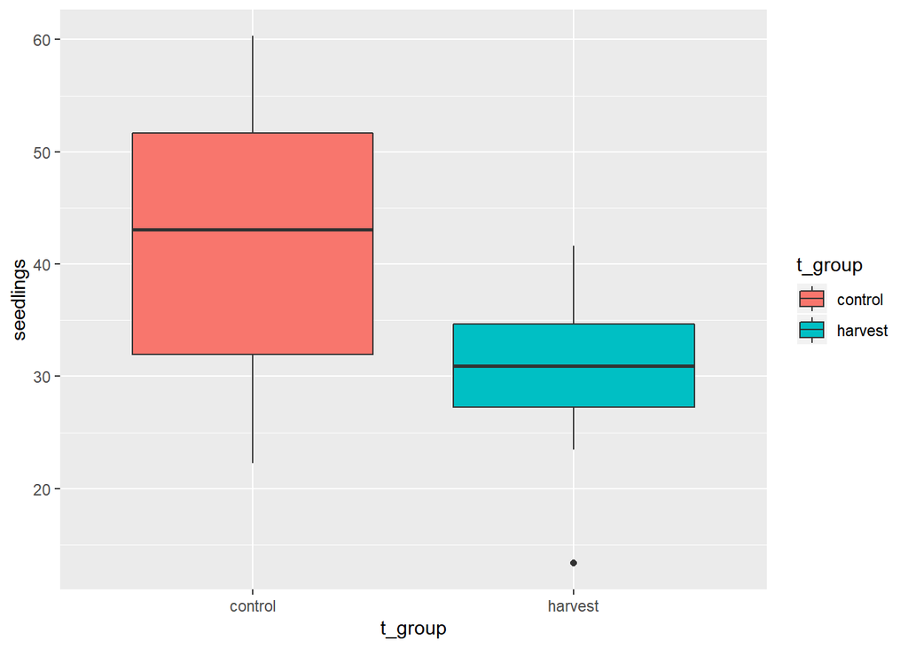

```r
library(ggplot2)

ano_plot <- ggplot(data=sim_data, #plotting the anova results
                   aes(x=t_group, #by treatment group
                       y=seedlings,
                   fill=t_group)) +
                   geom_boxplot() #specifies the type of graph we want
print(ano_plot)
```

### Varying the mean

In this section, I will vary the means of both groups to find out how close they can be while still showing a statistically significant difference.

```r
#Keeping all else the same, besides the mean......

for (i in 0:7){

n_mean2 <- c(45,30)

  n_mean2[1] = n_mean2[1]-i #bringing the means closer together
  n_mean2[2] = n_mean2[2]+i #with each iteration of the for loop

  #the new means are reflected in the response variable distributions
  seedlings <- c(rnorm(n=n_size[1],mean=n_mean2[1],sd=n_sd[1]),
             rnorm(n=n_size[2],mean=n_mean2[2],sd=n_sd[2]))

#creating the data frame
sim_data <- data.frame(id,t_group,seedlings)

#analyzing the data
ano_model <- aov(seedlings~t_group,data=sim_data)

#using code from last week as a model:
z <- summary(ano_model)

#for each iteration of effect size, this prints out the difference between the means, the associated p-value, and whether it's significant
print(paste("Effect size: ",
            n_mean[1]-n_mean[2],
            ", p-value: ",
            unlist(z)[9],
            ", significant? ",
            unlist(z)[9]<0.05))
}
```

```
## [1] "Effect size:  15 , p-value:  8.59199689681239e-07 , significant?  TRUE"
## [1] "Effect size:  15 , p-value:  1.4419910401621e-08 , significant?  TRUE"
## [1] "Effect size:  15 , p-value:  1.90109013935662e-05 , significant?  TRUE"
## [1] "Effect size:  15 , p-value:  0.0241095970449825 , significant?  TRUE"
## [1] "Effect size:  15 , p-value:  0.0996367506039618 , significant?  FALSE"
## [1] "Effect size:  15 , p-value:  0.0646694565810507 , significant?  FALSE"
## [1] "Effect size:  15 , p-value:  0.0578945713358112 , significant?  FALSE"
## [1] "Effect size:  15 , p-value:  0.220405241934069 , significant?  FALSE"
```

##### After running this code several times, I found that the significance was variable at all but the highest and lowest effect sizes I chose.

##### When the difference between the means was 15, the difference in the distributions was always significant.

##### When the difference between the means was 1, the difference in the distributions was never significant.

##### For all the effect sizes in between, it varied…

I could also add an outer for loop to run this code a bunch of times and find out how likely each effect size is to be significant.

### Varying the sample size

In this section, I will vary the sample size to find out how small it can be while still showing a statistically significant difference between the treatment groups (using my original effect size).

```r
#Keeping all else the same, besides the sample size...

for (i in seq(from=25,to=5,by=-5)){

n_size <- c(i,i)

t_group <- rep(n_name,n_size)
id <- 1:(sum(n_size))

#simulating data as the response variable:
seedlings <- c(rnorm(n=n_size[1],mean=n_mean[1],sd=n_sd[1]),
             rnorm(n=n_size[2],mean=n_mean[2],sd=n_sd[2]))

#creating the data frame
sim_data <- data.frame(id,t_group,seedlings)

#analyzing the data
ano_model <- aov(seedlings~t_group,data=sim_data)

#using code from last week as a model:
z <- summary(ano_model)

#for each iteration of effect size, this prints out the difference between the means, the associated p-value, and whether it's significant
print(paste("Sample size per group: ",
            i,
            ", p-value: ",
            unlist(z)[9],
            ", significant? ",
            unlist(z)[9]<0.05))
}
```

```
## [1] "Sample size per group:  25 , p-value:  9.5248803048064e-05 , significant?  TRUE"
## [1] "Sample size per group:  20 , p-value:  2.53230739896644e-05 , significant?  TRUE"
## [1] "Sample size per group:  15 , p-value:  0.00280517802379402 , significant?  TRUE"
## [1] "Sample size per group:  10 , p-value:  0.0114567543208486 , significant?  TRUE"
## [1] "Sample size per group:  5 , p-value:  0.317525829818426 , significant?  FALSE"
```

##### When the sample size per group was 10 or greater, the difference in the distributions was always significant.

##### However, at a sample size per group of 5, the difference in the distributions was sometimes significant, other times not.

##### Therefore, the minimum sample size I would need to detect a statistically significant effect is 10 samples per treatment group.